# gusto_cbcl_scoring

Fran Querdasi

3/18/2021

NOTE: Before running this script, please ensure that “gusto_cbcl_cleaning” has been run to create the cleaned, separated files.

This script takes in .csv files with individual timepoints of cleaned CBCL data at M24 and Y4. It creates ‘GI subscale’ scores (range = 0-8) and performs descriptive statistics for this subscale (Ns with subcale, distributions, whether scores differ across CBCL completed by mother vs. other respondent). It outputs files containing CBCL subscale scores + 2 descriptor variables (‘age’ [if applicable] and ‘mom_fill’) for each timepoint. Data have been filtered to only include participants with at least 1 subscale score (i.e., not all NAs for subscale scores).

# Setup

## load libraries

```r
library(tidyverse)
library(stats)
```

## import data

**Note:** Filepaths not shown

## calculate GI symptom subscale score (sum)

Each question: 0=not true, 1=somewhat true, 2=very true; subscale range=0-8

```r
m24_scored <-
  m24 %>%
  mutate(
    cbcl_gi_m24 = rowSums(cbind(cbcl_q45_nausea_m24, cbcl_q52_painbowel_m24, cbcl_q78_stomache_m24, cbcl_q93_vomit_m24))
  )

y4_scored <-
  y4 %>%
  mutate(
    cbcl_gi_y4 = rowSums(cbind(cbcl_q45_nausea_y4, cbcl_q52_painbowel_y4, cbcl_q78_stomache_y4, cbcl_q93_vomit_y4))
  )
```

## remove all unnecessary vars

```r
m24_scored <-
  m24_scored %>%
  dplyr::select(
    -cbcl_usability_m24,
    -cbcl_q45_nausea_m24,
    -cbcl_q52_painbowel_m24,
    -cbcl_q78_stomache_m24,
    -cbcl_q93_vomit_m24,
    -no_data
  )

y4_scored <-
  y4_scored %>%
  dplyr::select(
    -cbcl_usability_y4,
    -cbcl_q45_nausea_y4,
    -cbcl_q52_painbowel_y4,
    -cbcl_q78_stomache_y4,
    -cbcl_q93_vomit_y4,
    -no_data
  )
```

## GI ‘subscale’ scores quick descriptives

Ns, distributions, differences based on CBCL respondent

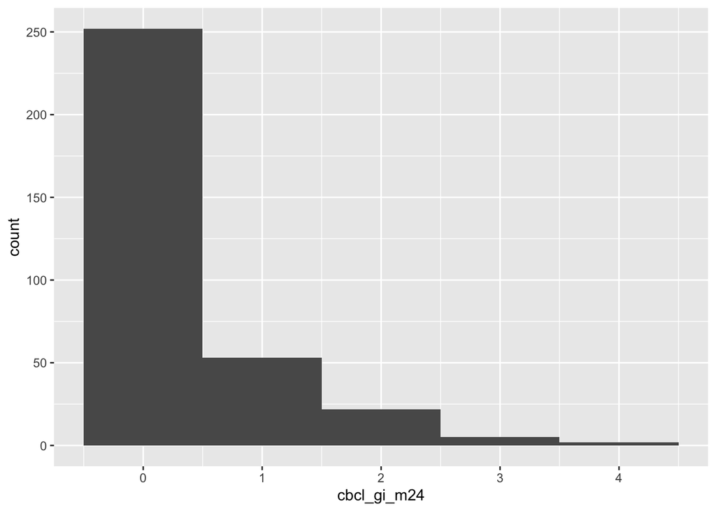

```r
#distribution of GI subscale scores
m24_scored %>%
  ggplot(aes(cbcl_gi_m24)) +
  geom_histogram(binwidth = 1)
```

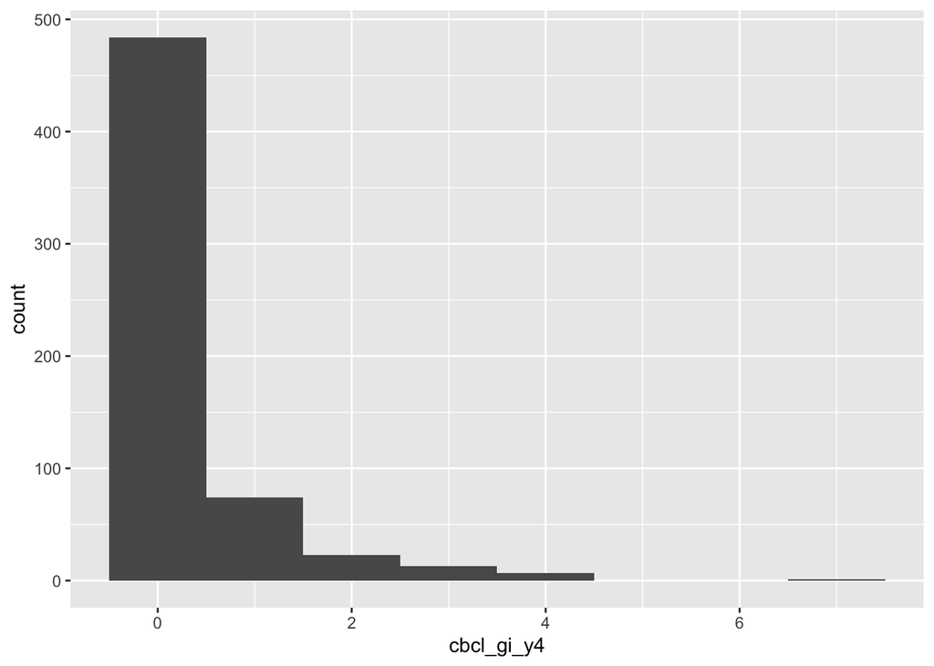

```r
y4_scored %>%
  ggplot(aes(cbcl_gi_y4)) +
  geom_histogram(binwidth = 1)
```

```r
#Number of participants at each timepoint with GI scores
m24_scored %>%
  count(!is.na(cbcl_gi_m24))
```

```
## # A tibble: 2 × 2
##   `!is.na(cbcl_gi_m24)`     n
##   <lgl>                 <int>
## 1 FALSE                     7
## 2 TRUE                    334
```

```r
y4_scored %>%
  count(!is.na(cbcl_gi_y4))
```

```
## # A tibble: 1 × 2
##   `!is.na(cbcl_gi_y4)`     n
##   <lgl>                <int>
## 1 TRUE                   602
```

```r
#Are there any significant differences in scores based on mother informant vs. other?
#1. make mom_fill var into factor
m24_scored$cbcl_mom_fill_m24 <- as.factor(m24_scored$cbcl_mom_fill_m24)
y4_scored$cbcl_mom_fill_y4 <- as.factor(y4_scored$cbcl_mom_fill_y4)

#2. perform t-tests to determine if there is a significant difference. No adjustment; considering each timepoint it's own family
pairwise.t.test(m24_scored$cbcl_gi_m24, m24_scored$cbcl_mom_fill_m24, pool.sd = FALSE, p.adjust = "none", paired = FALSE) #ns (0.12)
```

```
##
##  Pairwise comparisons using t tests with non-pooled SD
##
## data:  m24_scored$cbcl_gi_m24 and m24_scored$cbcl_mom_fill_m24
##
##   0
## 1 0.12
##
## P value adjustment method: none
```

```r
#cannot do t-est for Y4 because there was only 1 observation with mom_fill = 0
```

## Write output files

These files (1 per timepoint) have been filtered to only include participants that have at least 1 subscale score.  
The descriptive ‘age’ and ‘mom_fill’ variables have been left in for evaluation by analysis

```r
#output file names
out_file_name_M24 <- str_c("../../data/child_beh/GUSTO_CBCL_scores_M24_", str_replace_all(Sys.Date(), "-", ""), ".csv")

out_file_name_Y4 <- str_c("../../data/child_beh/GUSTO_CBCL_scores_Y04_", str_replace_all(Sys.Date(), "-", ""), ".csv")

#write output files
write_csv(m24_scored, out_file_name_M24)

write_csv(y4_scored, out_file_name_Y4)
```